# ISLR Q.14 pg 125

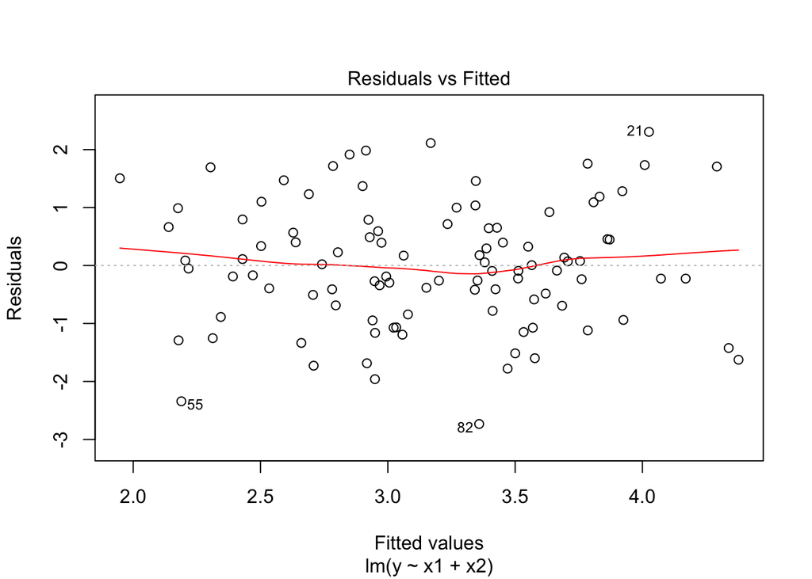

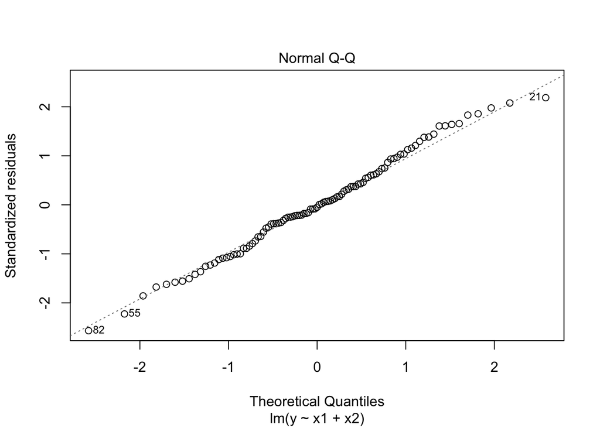

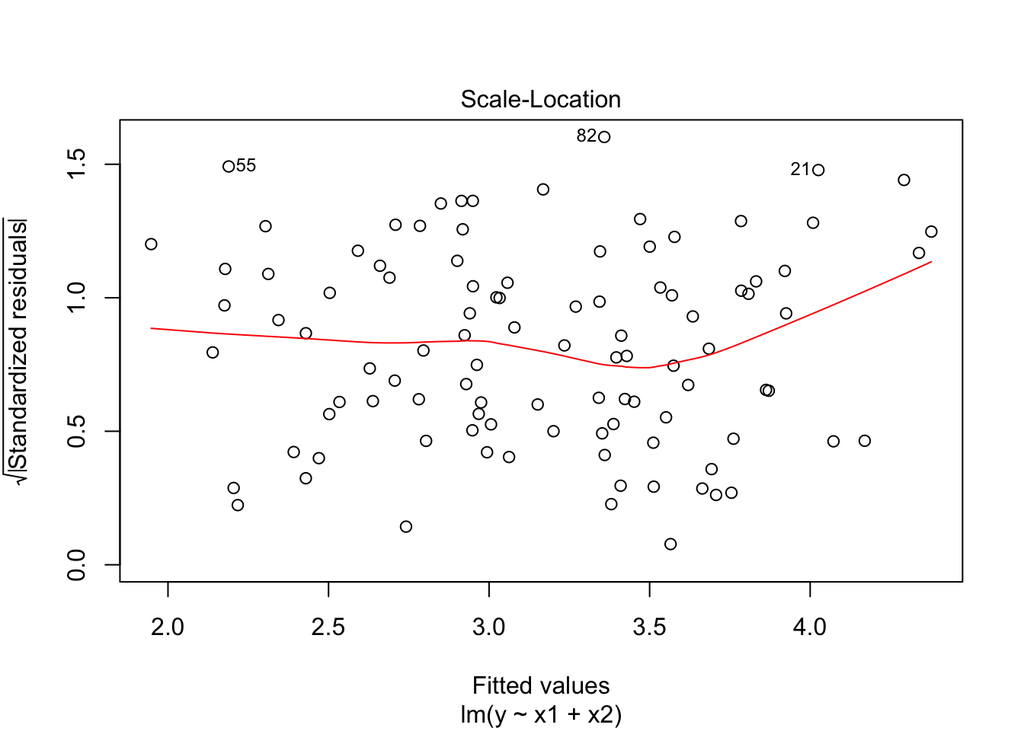

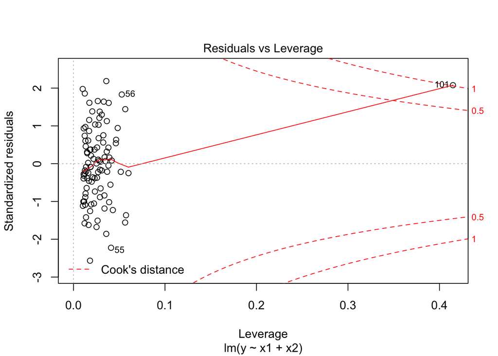

```r
plot(model4)
```

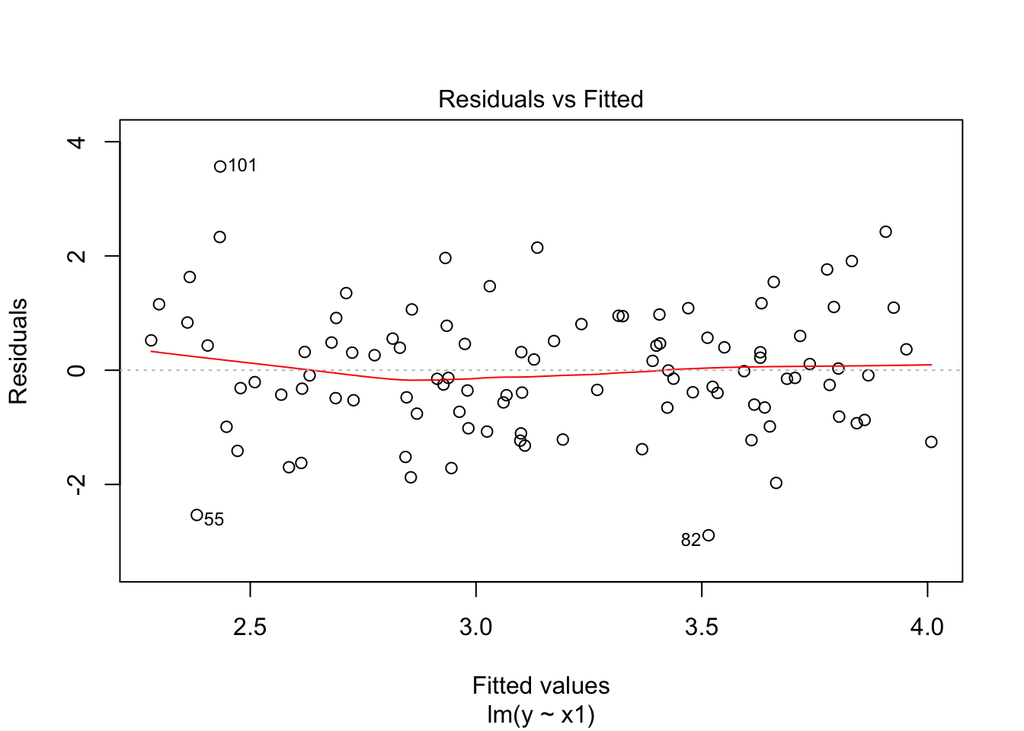

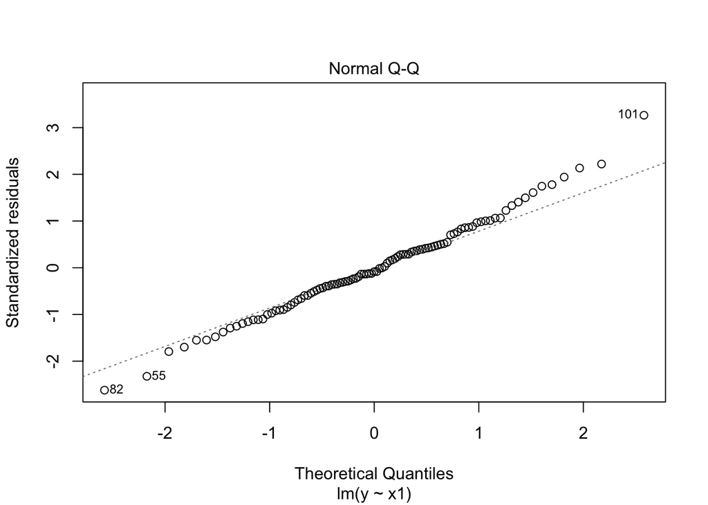

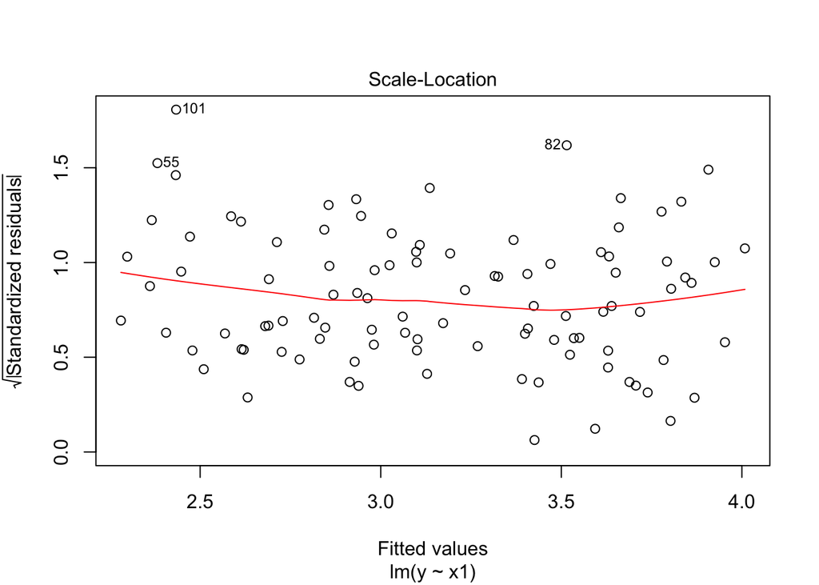

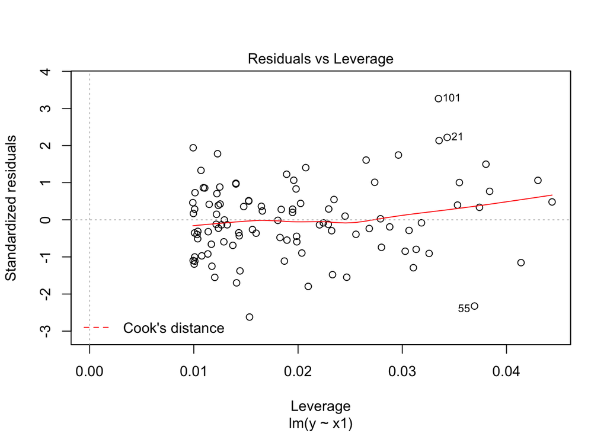

```r
plot(model5)
```

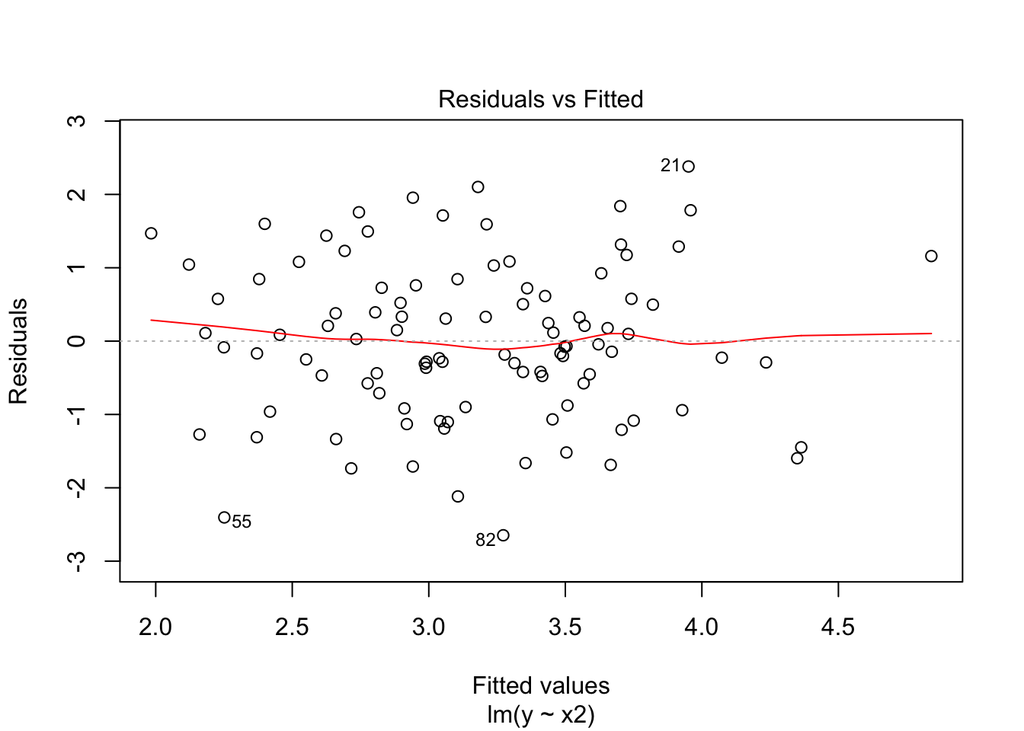

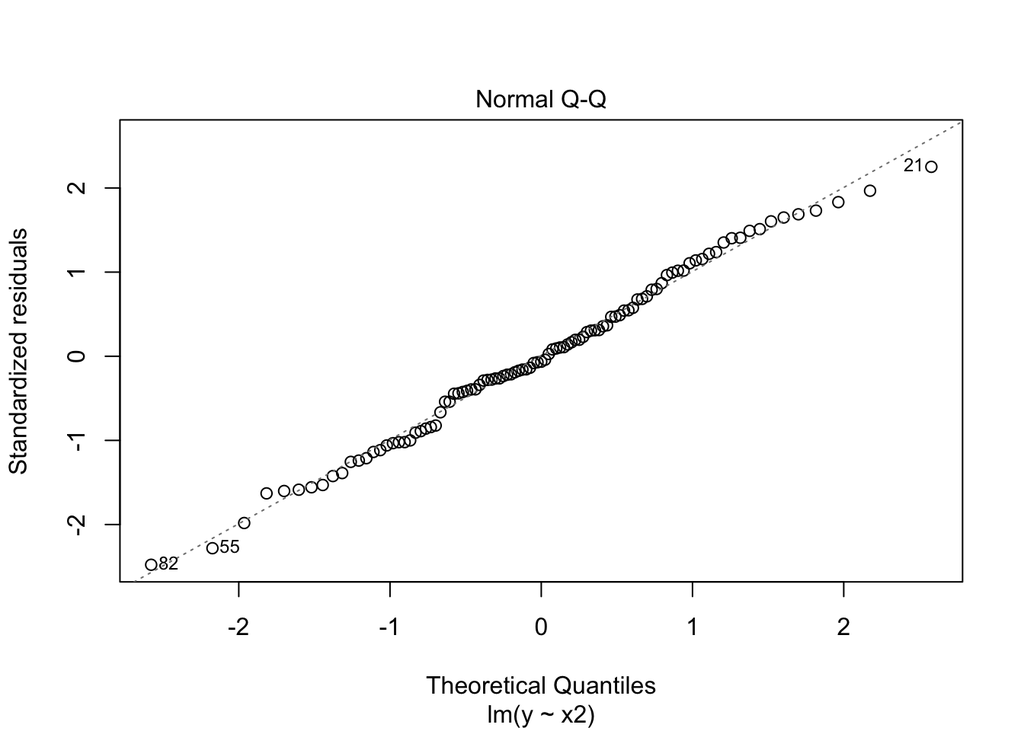

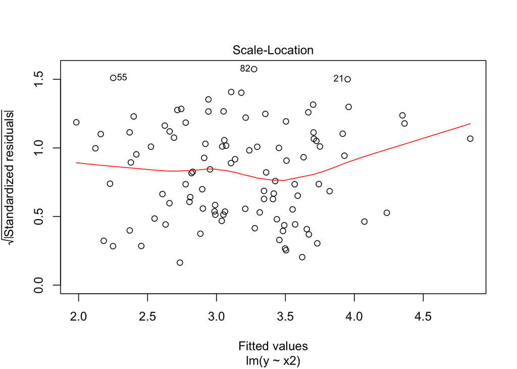

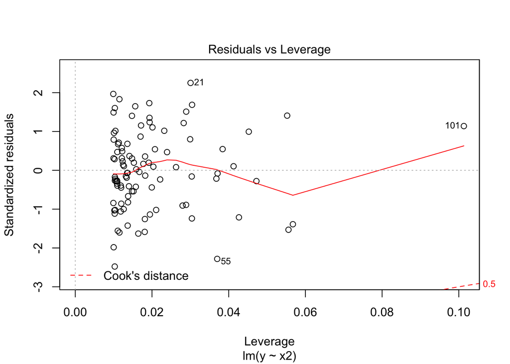

```r
plot(model6)
```

In the Residual vs. ftted graph for x1 and x2, we do see some overlapping of data points. This is apparently due to collinearity.

In the Residual vs. fitted graph for x2, a single predictor towards the rightmost is a high leverage point with high value of predictor.

In the model with x1, a single prdictor is an outlier, that is having an unusual response value.